# Modelos estatísticos de Redes - 01

Neylson Crepalde - GIARS

2016, June 4

Neste post abordaremos a última palavra em modelos estatísticos para dados relacionais os exponential random graph models, ou modelos p* (pê-estrela). Iniciaremos com um post mais técnico focado nos comandos e possíveis parâmetros do pacote **statnet**. No próximo post, abordaremos questões mais conceituais relacionadas aos modelos bem como sua interpretação.

Além disso, este post está organizado neste belo e eficiente layout chamado **Tufte Handout** inspirado nos livros e comunicações do prof. Edward Tufte. Para mais informações sobre o uso, vantagens e questões técnicas, consulte [este site](http://rmarkdown.rstudio.com/tufte_handout_format.html).

Os modelos p* foram desenvolvidos para dar conta de dados que assumem interdependência das observações. Ora, os modelos econométricos clássicos (regressão linear, regressão logística, etc.) assumem independência das observações e portanto não devem ser aplicados a dados relacionais. Em outras palavras, se A conhece C, a existência de um laço entre B e C altera a probabilidade de existência de um laço entre B e A.

Granovetter, M. S. (1973). The strength of weak ties. **American journal of sociology**, 1360-1380.

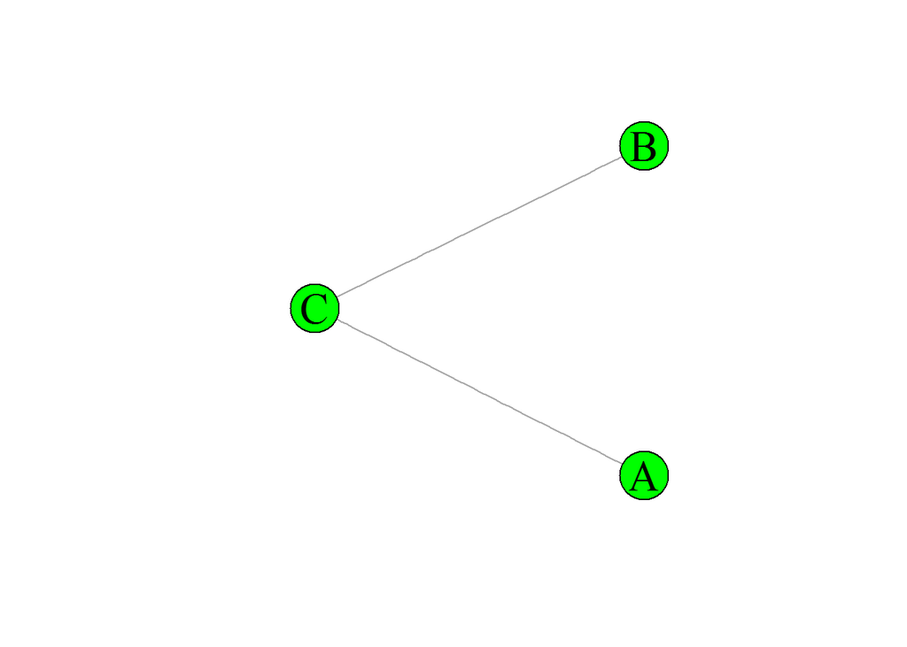

Granovetter’s impossible triad

O modelo p* pode ser definido por

$Pr(Y=y) \quad = \quad \left(\frac{1}{k}\right) exp \left\{ \sum_{A} \eta_A g_A (\textbf{y}) \right\}$

onde Y é o grafo teórico simulado, y é o grafo observado, $\sum_{A}$ é a soma de todas as configurações *A*, $\eta_A$ é o parâmetro estimado correpondente à configuração *A*, $g_A (\textbf{y})$ é a estatística da configuração *A* observada no grafo **y** e **k** é uma constante que assegura a distribuição de probabilidades.

Robins, Garry et al. An introduction to exponential random graph (p*) models for social networks. **Social networks**, Elsevier, v. 29, n. 2, p. 173–191, 2007.

Para estimar um modelo p* no R, usaremos os comandos da suite **statnet** e o pacote **igraph** para auxílio com a importação dos dados quando for o caso. Vamos ao primeiro exemplo.

## ERGM - Florentine Families

Vamos tentar modelar a rede casamentos de famílias de Florença do famoso trabalho de Padgett (1994). Primeiro, investiguemos a rede.

Padgett, John F. (1994) **Marriage and Elite Structure in Renaissance Florence**, 1282-1500. Paper delivered to the Social Science History Association.

```r
library(statnet)
library(sand)
library(intergraph)
```

```r
data(florentine)
flomarriage
```

```
##  Network attributes:
##   vertices = 16
##   directed = FALSE
##   hyper = FALSE
##   loops = FALSE
##   multiple = FALSE
##   bipartite = FALSE
##   total edges= 20
##     missing edges= 0
##     non-missing edges= 20
##
##  Vertex attribute names:
##     priorates totalties vertex.names wealth
##
## No edge attributes
```

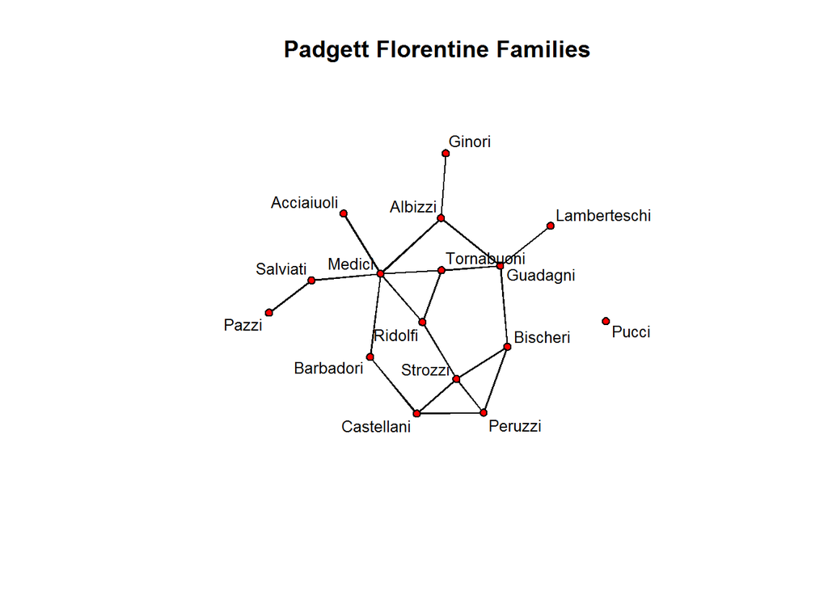

```r
plot(flomarriage, displaylabels=T,
     label.cex=0.8, main="Padgett Florentine Families")
```

Investiguemos agora os atributos. Como acho mais fácil fazer isso usando o pacote **igraph**, vamos a ele.

```r
marriage <- asIgraph(flomarriage)
V(marriage)$priorates
```

```
##  [1] 53 65  0 12 22  0 21  0 53  0 42  0 38 35 74  0
```

```r
V(marriage)$totalties
```

```
##  [1]  2  3 14  9 18  9 14 14 54  7 32  1  4  5 29  7
```

```r
V(marriage)$wealth
```

```
##  [1]  10  36  55  44  20  32   8  42 103  48  49   3  27  10 146  48
```

Podemos plotar a rede representando algum atributo. Vamos representar a *riqueza* com o tamanho dos vértices. Como o pacote **igraph** lê os valores absolutos e o grafo fica muito poluído, vamos dividir o vetor de valores de riqueza por 4 para uma visualização mais limpa.

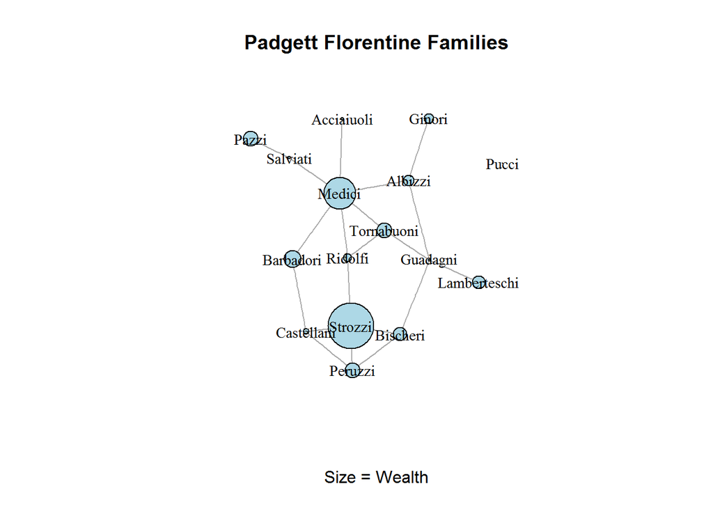

```r
plot(marriage, vertex.label.cex=0.9,
     vertex.label=V(marriage)$vertex.names,
     vertex.size=V(marriage)$wealth/4,
     vertex.color="lightblue",
     vertex.label.color="black",
     main = "Padgett Florentine Families",
     xlab="Size = Wealth")
```

Agora vamos à modelagem. Primeiro, é comum estimarmos o *modelo nulo*, ou seja, um modelo apenas com o parâmetro **edges** que corresponde ao intercepto dos modelos econométricos comuns. Este modelo toma a díade por unidade de análise e estima a “propensão dos atores a escolherem outros atores, serem escolhidos por outros, a fazer escolhas recíprocas e a tendência média (parâmetro de densidade) a interagir com os outros (Lazega & Higgins, 2014, p. 81).

Este modelo é também conhecido como $P_1$ e foi desenvolvido por Holland e Leinhardt.

Lazega, E., & Higgins, S. S. (2014). **Redes sociais e estruturas relacionais**. Belo Horizonte, MG: Fino Traço.

```r
fit1 <- ergm(flomarriage~edges)
```

```r
summary(fit1)
```

```
##
## ==========================
## Summary of model fit
## ==========================
##
## Formula:   flomarriage ~ edges
##
## Iterations:  5 out of 20
##
## Monte Carlo MLE Results:
##       Estimate Std. Error MCMC % p-value
## edges  -1.6094     0.2449      0  <1e-04 ***
## ---
## Signif. codes:  0 '***' 0.001 '**' 0.01 '*' 0.05 '.' 0.1 ' ' 1
##
##      Null Deviance: 166.4  on 120  degrees of freedom
##  Residual Deviance: 108.1  on 119  degrees of freedom
##
## AIC: 110.1    BIC: 112.9    (Smaller is better.)
```

O parâmetro negativo e significativo nos mostra que esta rede se desenvolve com menos laços entre seus atores do que esperaríamos numa rede aleatória. Em seguida, vamos estimar um modelo controlando por triângulos e por distribuição de laços compartilhados geometricamente pesada (*gwesp*). Vamos usar os comandos **formula** e **summary.statistics** para contar as estatísticas existentes na rede original.

No próximo post pretendo explicar melhor o conceito teórico de rede aleatória e como ele é mobilizado na interpretação dos ERGMs.

*Geometrically weighted edgewise shared partner distribution*.

```r
model2 <- formula(flomarriage~edges+triangle+
                    gwesp(1,fixed=T))
summary.statistics(model2)
```

```
##         edges      triangle gwesp.fixed.1
##     20.000000      3.000000      8.632121
```

Em seguida, “rodamos” o modelo.

```r
fit2 <- ergm(model2)
```

```r
summary(fit2)
```

```
##
## ==========================
## Summary of model fit
## ==========================
##
## Formula:   flomarriage ~ edges + triangle + gwesp(1, fixed = T)
##
## Iterations:  2 out of 20
##
## Monte Carlo MLE Results:
##               Estimate Std. Error MCMC % p-value
## edges          -1.7307     0.3754      0  <1e-04 ***
## triangle       -4.3617     8.7671      0   0.620
## gwesp.fixed.1   1.7068     3.1747      0   0.592
## ---
## Signif. codes:  0 '***' 0.001 '**' 0.01 '*' 0.05 '.' 0.1 ' ' 1
##
##      Null Deviance: 166.4  on 120  degrees of freedom
##  Residual Deviance: 107.6  on 117  degrees of freedom
##
## AIC: 113.6    BIC: 122    (Smaller is better.)
```

Às vezes é útil avaliar o processo de amostragem por *Monte Carlo Markov Chain* (MCMC). Para isso, usamos o comando `plot()`.

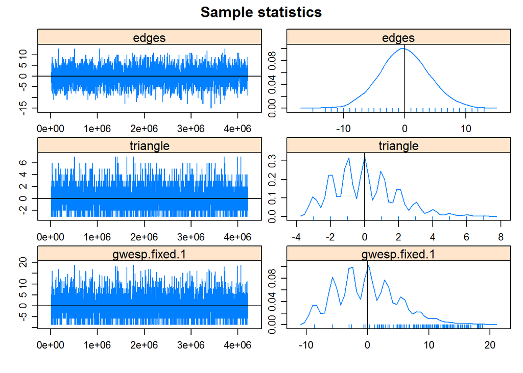

```r
plot(fit2)
```

```
## Sample statistics summary:
##
## Iterations = 16384:4209664
## Thinning interval = 1024
## Number of chains = 1
## Sample size per chain = 4096
##
## 1. Empirical mean and standard deviation for each variable,
##    plus standard error of the mean:
##
##                   Mean    SD Naive SE Time-series SE
## edges         -0.03442 3.995  0.06242        0.06242
## triangle      -0.02246 1.853  0.02896        0.02896
## gwesp.fixed.1 -0.05941 5.161  0.08064        0.08064
##
## 2. Quantiles for each variable:
##
##                 2.5% 25%       50% 75% 97.5%
## edges         -8.000  -3 0.000e+00   3  8.00
## triangle      -3.000  -1 0.000e+00   1  4.00
## gwesp.fixed.1 -8.632  -3 2.119e-12   3 11.26
##
##
## Sample statistics cross-correlations:
##                   edges  triangle gwesp.fixed.1
## edges         1.0000000 0.7375073      0.742671
## triangle      0.7375073 1.0000000      0.998088
## gwesp.fixed.1 0.7426710 0.9980880      1.000000
##
## Sample statistics auto-correlation:
## Chain 1
##                edges    triangle gwesp.fixed.1
## Lag 0    1.000000000 1.000000000   1.000000000
## Lag 1024 0.001902441 0.006472082   0.005209743
## Lag 2048 0.006939257 0.011665822   0.011808763
## Lag 3072 0.016012409 0.010663944   0.012128877
## Lag 4096 0.030240606 0.005898352   0.005916047
## Lag 5120 0.031856924 0.005182487   0.004993409
##
## Sample statistics burn-in diagnostic (Geweke):
## Chain 1
##
## Fraction in 1st window = 0.1
## Fraction in 2nd window = 0.5
##
##         edges      triangle gwesp.fixed.1
##      -0.08226       0.91539       0.91474
##
## Individual P-values (lower = worse):
##         edges      triangle gwesp.fixed.1
##     0.9344393     0.3599844     0.3603262
## Joint P-value (lower = worse):  0.6102331 .
```

[output not shown]

Para verificar o ajuste e a convergência do modelo, usamos o comando `gof()`.

```r
gof2 <- gof(fit2)
```

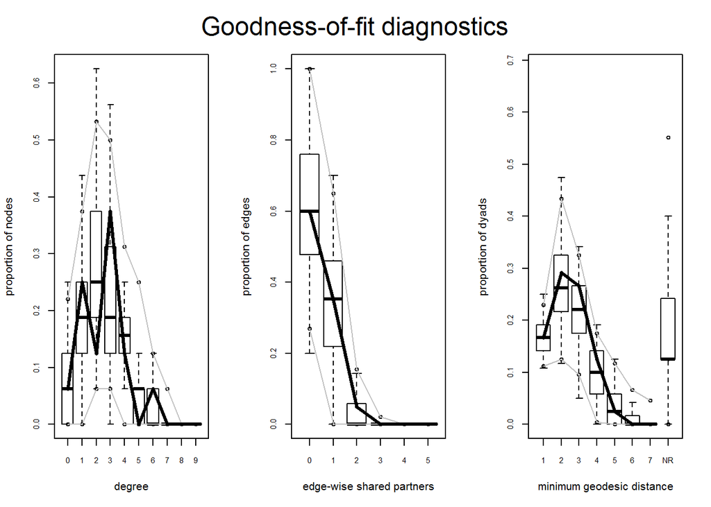

```r
par(mfrow=c(1,3))
plot(gof2)
```

O modelo parece se ajustar bem aos dados. Este modelo convergiu e podemos confiar nos parâmetros estimados para explicar a emergência de nossa rede observada. Neste caso, observando os resultados, apesar de triângulos e distribuição de laços compartilhados terem estimadores respectivamente negativo e postivo, eles não são estatisticamente significativos indicando que essas configurações não são importantes para entendermos o surgimento da rede.

Agora, como outro exemplo, vamos trabalhar com os dados dos advogados de Lazega.

## ERGM - Lazega’s lawyers

Estes dados estão no pacote **sand**. Precisamos transformá-los num objeto de classe network para realizar a estimação do p*.

```r
lazega <- upgrade_graph(lazega)
lawyers <- asNetwork(lazega)
```

```r
fit1 <- ergm(lawyers~edges)
```

```r
summary(fit1)
```

```
##
## ==========================
## Summary of model fit
## ==========================
##
## Formula:   lawyers ~ edges
##
## Iterations:  5 out of 20
##
## Monte Carlo MLE Results:
##       Estimate Std. Error MCMC % p-value
## edges  -1.4992     0.1031      0  <1e-04 ***
## ---
## Signif. codes:  0 '***' 0.001 '**' 0.01 '*' 0.05 '.' 0.1 ' ' 1
##
##      Null Deviance: 873.4  on 630  degrees of freedom
##  Residual Deviance: 598.8  on 629  degrees of freedom
##
## AIC: 600.8    BIC: 605.2    (Smaller is better.)
```

Depois de estimar o modelo $P_1$, vamos estimar um modelo com triângulos e distribuição de laços compartilhados.

```r
model2 <- formula(lawyers~edges+triangle+
                    gwesp(1,fixed=T))
summary.statistics(model2)
```

```
##         edges      triangle gwesp.fixed.1
##      115.0000      120.0000      213.1753
```

```r
fit2 <- ergm(model2)
```

```r
summary(fit2)
```

```
##
## ==========================
## Summary of model fit
## ==========================
##
## Formula:   lawyers ~ edges + triangle + gwesp(1, fixed = T)
##
## Iterations:  2 out of 20
##
## Monte Carlo MLE Results:
##               Estimate Std. Error MCMC % p-value
## edges          -3.6720     0.3211      0 < 1e-04 ***
## triangle       -0.2216     0.2190      0 0.31215
## gwesp.fixed.1   0.9822     0.2538      0 0.00012 ***
## ---
## Signif. codes:  0 '***' 0.001 '**' 0.01 '*' 0.05 '.' 0.1 ' ' 1
##
##      Null Deviance: 873.4  on 630  degrees of freedom
##  Residual Deviance: 519.8  on 627  degrees of freedom
##
## AIC: 525.8    BIC: 539.2    (Smaller is better.)
```

Vamos ver o ajuste desse modelo aos dados e sua convergência.

```r
gof2 <- gof(fit2)
```

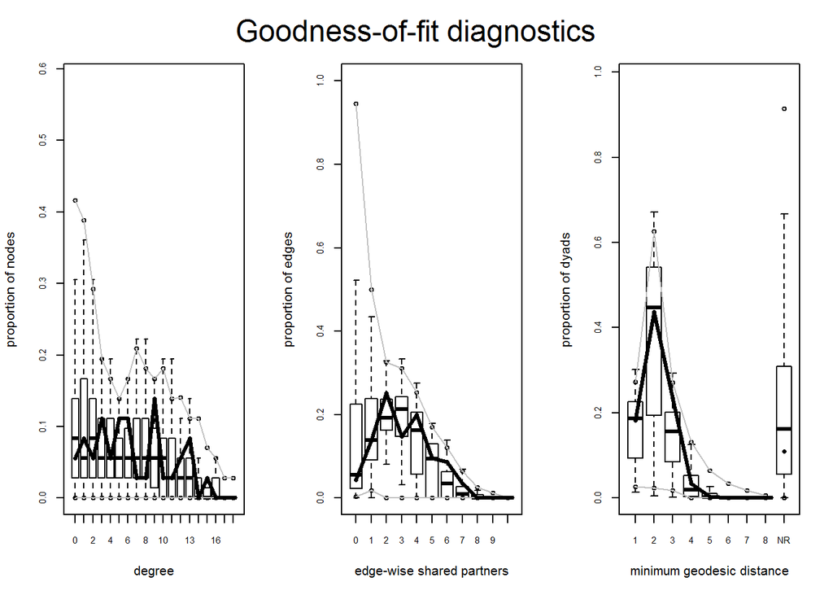

```r
par(mfrow=c(1,3))
plot(gof2)
```

Vamos tentar elaborar um modelo um pouco mais complexo usando algumas estatísticas a mais além dos atributos dos atores. Dessa vez vamos modelar ainda a distribuição de grau e os atributos *gênero*, *escritório* que pertence, *escola* de origem, *idade* e *senioridade*. Atributos qualitativos são inseridos no modelo por semelhança. Atributos quantitativos são inseridos, neste caso, somando-se os valores de díades para todos os atores na rede. A lista de estatísticas possíveis é longa e podemos investigá-la com o comando `help("ergm-terms")`. Vamos ao modelo:

```r
model3 <- formula(lawyers~edges+triangle+
                    gwesp(1,fixed=T)+gwdegree(1,fixed=T)+
                    nodematch("Gender")+nodematch("Office")+
                    nodematch("School")+nodecov("Age")+
                    nodecov("Seniority"))
summary.statistics(model3)
```

```
##             edges          triangle     gwesp.fixed.1          gwdegree
##          115.0000          120.0000          213.1753           79.2000
##  nodematch.Gender  nodematch.Office  nodematch.School       nodecov.Age
##           99.0000           85.0000           36.0000        10526.0000
## nodecov.Seniority
##         4687.0000
```

```r
fit3 <- ergm(model3)
```

```r
summary(fit3)
```

```
##
## ==========================
## Summary of model fit
## ==========================
##
## Formula:   lawyers ~ edges + triangle + gwesp(1, fixed = T) + gwdegree(1,
##     fixed = T) + nodematch("Gender") + nodematch("Office") +
##     nodematch("School") + nodecov("Age") + nodecov("Seniority")
##
## Iterations:  3 out of 20
##
## Monte Carlo MLE Results:
##                    Estimate Std. Error MCMC %  p-value
## edges              1.238827   2.407460      0 0.607031
## triangle          -0.148988   0.224826      0 0.507781
## gwesp.fixed.1      0.943846   0.280924      0 0.000828 ***
## gwdegree           0.468504   0.633291      0 0.459706
## nodematch.Gender   0.342240   0.218447      0 0.117696
## nodematch.Office   0.985246   0.182096      0  < 1e-04 ***
## nodematch.School   0.004201   0.256795      0 0.986953
## nodecov.Age       -0.052819   0.018697      0 0.004879 **
## nodecov.Seniority -0.025280   0.015257      0 0.098026 .
## ---
## Signif. codes:  0 '***' 0.001 '**' 0.01 '*' 0.05 '.' 0.1 ' ' 1
##
##      Null Deviance: 873.4  on 630  degrees of freedom
##  Residual Deviance: 475.5  on 621  degrees of freedom
##
## AIC: 493.5    BIC: 533.6    (Smaller is better.)
```

Para exemplos de interpretação, veja Lusher, Koskinen & Robins (2012) e Salej Higgins et al (2014)

Salej Higgins, S., Ribeiro, A., Botrel de Vasconcellos, M., & Estevão Barbosa, J. (2014). L’émergence d’une structure cœur-périphérie dans un réseau brésilien de copublications en sciences comptables. Communiquer. **Revue de communication sociale et publique**, (12), 43-60.

Vamos agora investigar o ajuste do modelo aos dados e sua convergência.

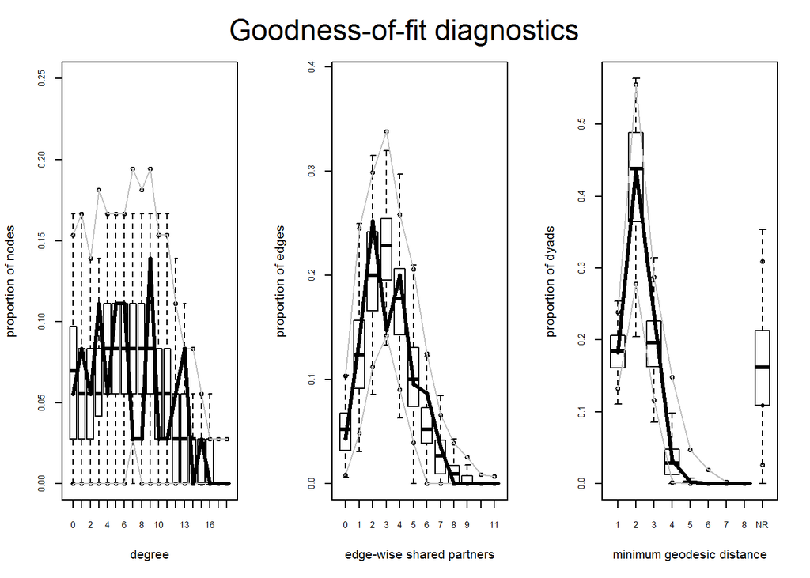

```r
gof3 <- gof(fit3)
par(mfrow=c(1,3))
plot(gof3)
```

Quando trabalhamos com modelos p*, as possibilidades são enormes. Devemos testar várias configurações de estatísticas modeladas de acordo com o que pretendemos investigar na rede em questão e com o ajuste do modelo aos dados.

## Algoritmos

O algoritmo default pelo qual o pacote statnet realiza a estimação dos modelos p* é o **Geyer-Thompson (1992)** (MCMLE). Este algoritmo costuma retornar os melhores resultados mas, por ser extremamente exigente (os modelos devem convergir 2 vezes, do contrário, o comando dá erro e para) pode não rodar para algumas redes mais extensas. O pacote **statnet** permite o uso de mais três algoritmos além do MCMLE: o algoritmo **Robbins-Monro** (usado pela família de softwares PNET), **Metropolis-Hastings** (aproximação estocástica) e **Stepping**. Vamos realizar a estimação do modelo 3 para os dados de Lazega com os outros 3 algoritmos e vamos compará-los.

Lusher, D., Koskinen, J., & Robins, G. (2012). **Exponential random graph models for social networks: Theory, methods, and applications.** Cambridge University Press.

```r
fit3.rb <- ergm(model3,
                control=control.ergm(main.method = "Robbins-Monro"))
fit3.sa <- ergm(model3,
                control=control.ergm(main.method = "Stochastic-Approximation"))
fit3.step <- ergm(model3,
                  control=control.ergm(main.method = "Stepping"))
```

```r
library(texreg)
```

```r
htmlreg(list(fit3, fit3.rb, fit3.sa, fit3.step),
          single.row=T, caption.above = T,
          custom.model.names=c("Geyer-Thompson", "Robbins-Monro","Metropolis-Hastings","Stepping"))
```

Statistical models

|  | **Geyer-Thompson** | **Robbins-Monro** | **Metropolis-Hastings** | **Stepping** |  |
| --- | --- | --- | --- | --- | --- |
| edges | 1.24 (2.41) | -0.51 | 0.17 (2.59) | 1.32 (2.51) |  |
| triangle | -0.15 (0.22) | -0.07 | -0.05 (0.22) | -0.15 (0.25) |  |
| gwesp.fixed.1 | 0.94 (0.28)*** | 0.97 | 0.82 (0.32)* | 0.94 (0.29)** |  |
| gwdegree | 0.47 (0.63) | 1.28 | 1.01 (0.69) | 0.46 (0.65) |  |
| nodematch.Gender | 0.34 (0.22) | 0.83 | 0.25 (0.24) | 0.33 (0.23) |  |
| nodematch.Office | 0.99 (0.18)*** | 0.49 | 0.73 (0.22)*** | 0.99 (0.18)*** |  |
| nodematch.School | 0.00 (0.26) | -0.19 | 0.10 (0.24) | -0.00 (0.24) |  |
| nodecov.Age | -0.05 (0.02)** | -0.04 | -0.04 (0.02)* | -0.05 (0.02)** |  |
| nodecov.Seniority | -0.03 (0.02) | -0.02 | -0.02 (0.02) | -0.03 (0.02) |  |
| AIC | 493.54 | 511.64 | 507.21 | 494.06 |  |
| BIC | 533.55 | 551.65 | 547.22 | 534.08 |  |
| Log Likelihood | -237.77 | -246.82 | -244.61 | -238.03 |  |
| p < 0.001, p < 0.01, p < 0.05 |  |  |  |  |  |

Vamos verificar o ajuste dos modelos estimados com os outros algoritmos.

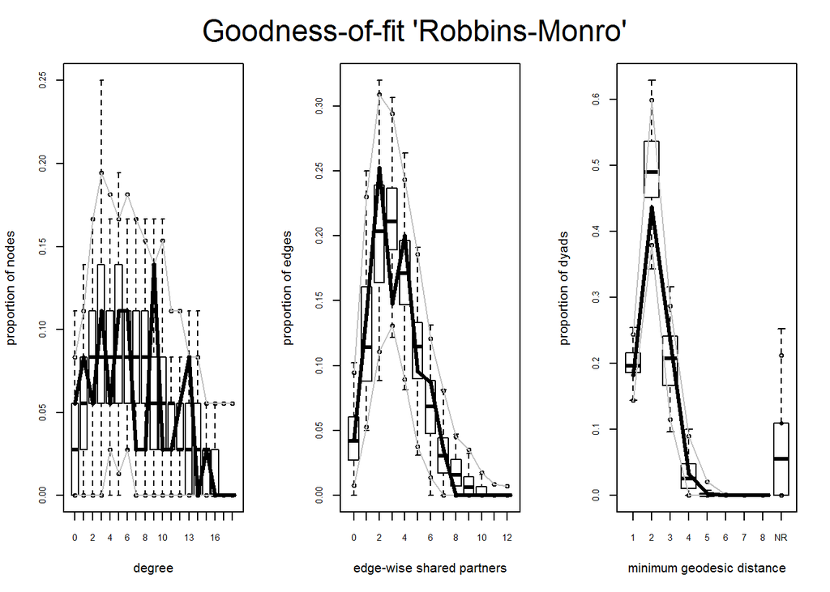

```r
gof3.rb <- gof(fit3.rb)
gof3.sa <- gof(fit3.sa)
gof3.step <- gof(fit3.step)
par(mfrow=c(1,3))
plot(gof3.rb,
     main = "Goodness-of-fit 'Robbins-Monro'")
```

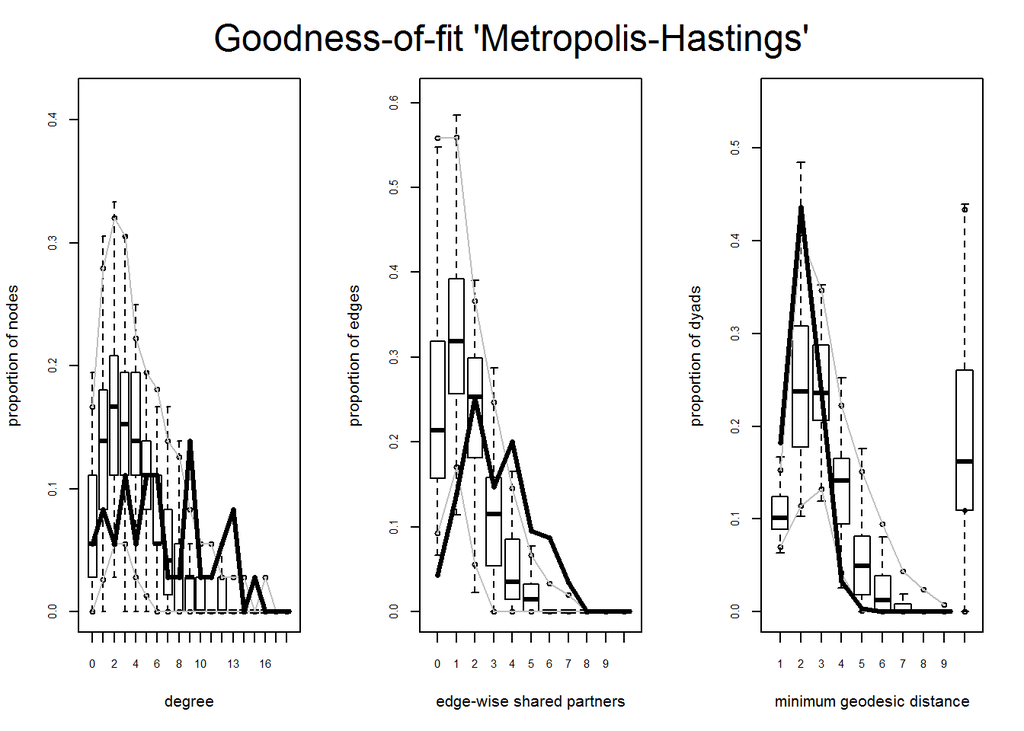

```r
plot(gof3.sa,
     main = "Goodness-of-fit 'Metropolis-Hastings'")
```

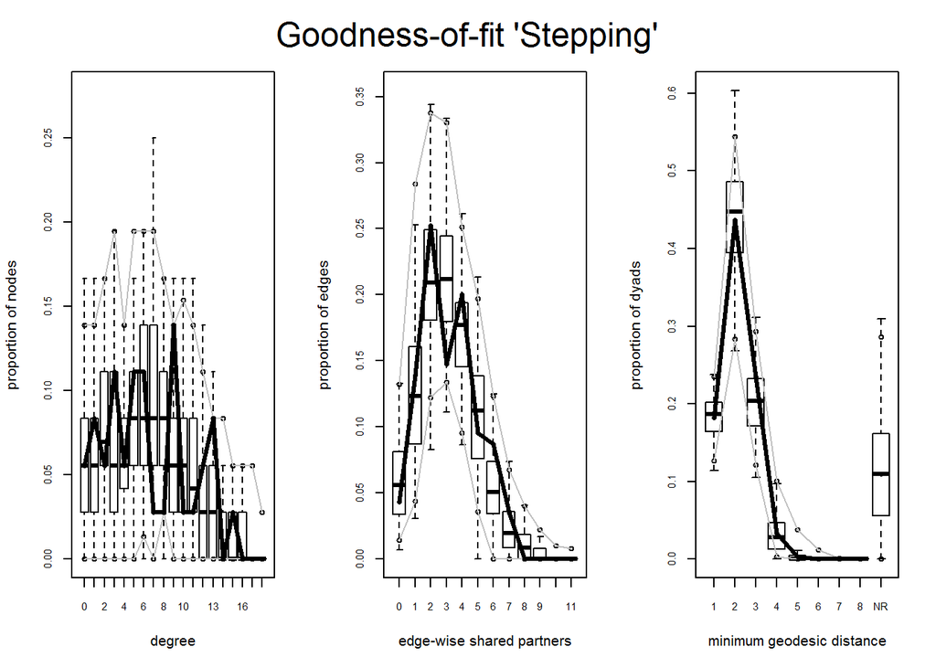

```r
plot(gof3.step,
     main="Goodness-of-fit 'Stepping'")
```

## É importante lembrar que…

A estimação de um modelo p* pode ser um processo longo e cansativo. Não há testes ou métodos para escolha prévia de um modelo a não ser o bom e velho “tentativa e erro”. A partir do seu problema de pesquisa, escolha os parâmetros que deseja estimar e vá melhorando o modelo escolhendo outros parâmetros. Muita atenção: o modelo deve convergir e os parâmetros estimados devem estar dentro dos limites dos plots de **Goodness-of-fit**. O algoritmo Geyer-Thompson tem a vantagem (ou não) de não rodar quando o modelo não converge. Os outros algoritmos rodam de qualquer modo e checamos se o modelo está degenerado pelo GOF. É importantíssimo salientar que **o modelo deve convergir completamente**. Um modelo que não converge em algum de seus parâmetros não quer dizer absolutamente nada (Lusher, Koskinem & Robins, 2012).

Lusher, D., Koskinen, J., & Robins, G. (2012). **Exponential random graph models for social networks: Theory, methods, and applications.** Cambridge University Press.